# Correlation

## Prerequisites

Make sure to be familiar with the following tutorials before proceeding:

- Variable Sets

## 1. Introduction

In a similar fashion to clustering correlation analysis in `cypro` is conducted on the base of variable sets.

```r
# load packages
library(cypro)

# load object from broad institute compound profiling experiment week 4
# contains one time imaging data
object <- readRDS(file = "data/bids-week4.RDS")

# load object that contains tracking data
object_tracks <- readRDS(file = "data/example-tracks.RDS")
```

## 2 Initiate correlation

We introduced variable sets with examples in which they contained only variables of one kind (e.g. shape or intensity). However, variable sets can contain as many variables of as many different kinds as desired.

```r
granularity_vars <- getStatVariableNames(object, starts_with("Granularity"))

intensity_vars <- getVariableSet(object, "intensity")

object <- addVariableSet(object, variable_names = c(granularity_vars, intensity_vars), set_name = "gran_intensity")
```

Once the variable set is defined you can set up the correlation analysis with `initiateCorrelation()`.

```r
object <- initiateCorrelation(object, variable_set = "gran_intensity")
```

## 3. Computation

`cypro` allows to compute correlation without regarding grouping options or in a comparative manner. The function `correlateAll()`takes all variables in the defined variables set and calculates correlation as well as belonging p-values.

```r
object <- correlateAll(object, variable_set = "gran_intensity", method_corr = "pearson")
```

The function `correlateAcross()` allows to additionally specify grouping variables according to which data is split before calculating correlation. This comes in very handy when to investigate in how far the relation between variables changes across cell lines or cluster or in how far the relation is disturb under certain conditions.

```r
object <- correlateAcross(object, variable_set = "gran_intensity", across = c("cell_line", "condition"))
```

[output not shown]

As in clustering all results are stored separately in the *cypro* object and can be plotted and extracted as well as they can expanded with computations for grouping variables that are added after `initiateCorrelation()`. For instance, if you have added a new clustering variable via `addKmeansClusterVariables()` and you now want to compute the correlation for all variables across these clustering results just use `correlateAcross()`again and specify the clustering name with the argument `across`.

```r
# add cluster variable
object <- addKmeansClusterVariables(object, variable_set = "area", k = 4, method_kmeans = "Lloyd")

# obtain respective name
getClusterVariableNames(object, contains(c("kmeans", "area", "4")))

# add another comparative correlation
object <- correlateAcross(object, variable_set = "gran_intensity", across = "kmeans_Lloyd_k_4_(area)")
```

## 4. Visualize

The function `plotCorrplot()` comes with a lot of options to visualize the relation between variables. You find a detailed description of how it works by typing `?plotCorrplot` in your R console. Below are some examples of how to visualize your results. Note: `plotCorrplots()` returns a ggplot. This has the advantage that it is very flexible and can be adjusted even after plotting. A drawback is, that geometric objects like circles or rectangulars have to be adjusted in size manually to be aesthetically pleasing.

As variable names occupy a lot of space in correlation plots we use `renameStatsDfWith()` to shorten the stat variable names. The tutorial about renaming elaborates on how to do that.

```r
object <-
  renameStatsDfWith(object = object,
                    .fn = ~ str_remove_all(.x, pattern = "^Intensity_|_Actin"), # remove redundant pre- and suffixes ...
                    .cols = starts_with(c("Intensity", "Granularity")) # ... of variables that start with either of both names
                    )
```

### 4.1 Correlation plots

`plotCorrplot()` without specifying argument across visualizes the correlation values of variables irrespective of cell grouping.

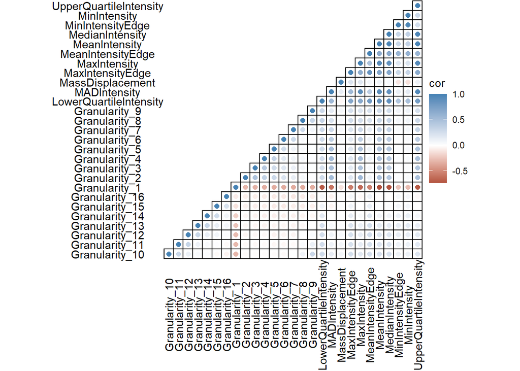

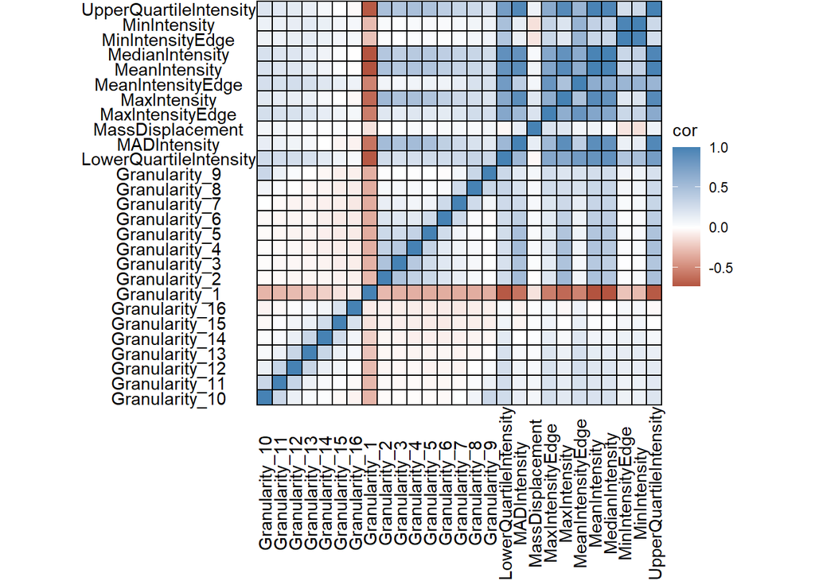

Figure 4.1 Basic correlation plots come in a variety of shapes and aesthetics.

```r
plotCorrplot(object, variable_set = "gran_intensity", plot_type = "lower", shape = "circle", shape_size = 2)

plotCorrplot(object, variable_set = "gran_intensity", plot_type = "complete")
```

### 4.2 Correlation across groups

Using argument `across` allows to investigate changes in variables relations in different groups. `across_subset` allows to specify the the groups of interest.

```r
# obtain valid input options for across_subset
conditions <- getConditions(object)
```

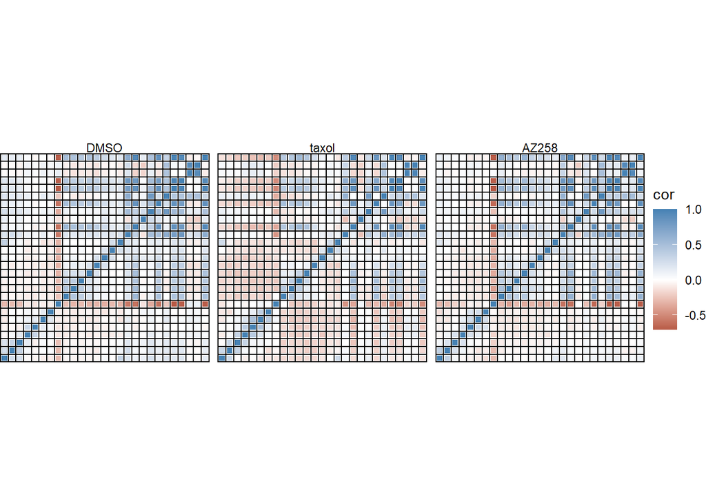

Figure 4.2 Comparative correlation plots.

```r
plotCorrplot(object = object,
             variable_set = "gran_intensity",
             plot_type = "complete",
             shape = "rect",
             shape_size = 1.5,
             across = "condition",
             across_subset = c("DMSO", "taxol", "AZ258"),
             nrow = 1) +
  labelsXremove() +
  labelsYremove()
```

### 4.3 Significance levels

By specifying argument `signif_level` you can set a maximum p-value threshold for the correlation. All correlations with a p-value above that threshold are crossed out.

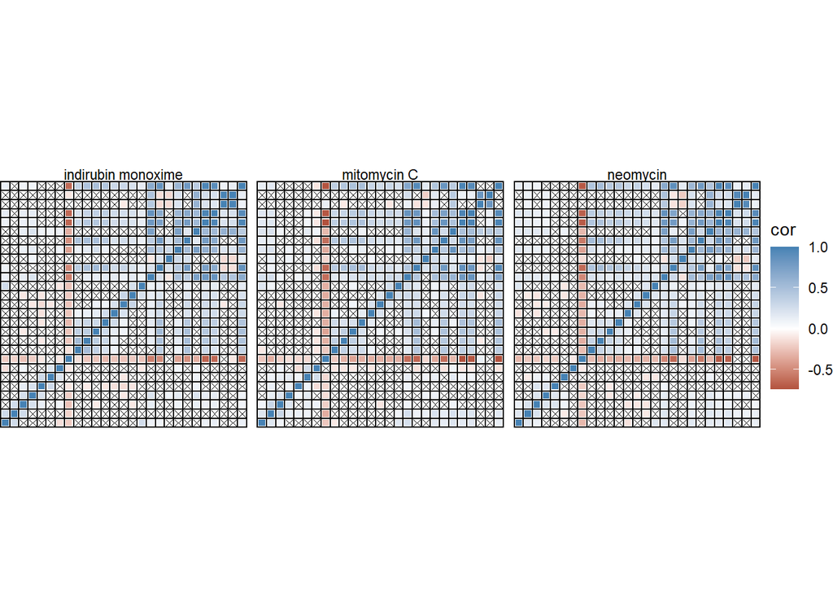

Figure 4.3 Integrate significance thresholds.

```r
plotCorrplot(object = object,
             variable_set = "gran_intensity",
             plot_type = "complete",
             shape = "rect",
             shape_size = 1.5,
             signif_level = 0.01,
             across = "condition",
             across_subset = c("indirubin monoxime","mitomycin C","neomycin"),
             nrow = 1) +
  labelsXremove() +
  labelsYremove()
```

## 5. Extraction

Correlation results are stored in the `@analysis`-slot under `$correlation`. Every correlation for every variable set is stored in a specific S4-object as programmed in the package [`confuns`](https://github.com/kueckelj/confuns/blob/master/R/correlation-wrapper.R) called *corr_conv*. Use the function `getCorrObject()` to extract the S4-objects containing all data needed including correlation matrices and p-values.